# Provincial Groundwater Observation Well Network (PGOWN)

Snapshot Report: Feb 2025

The Provincial Groundwater Observation Well Network Snapshot has taken place every year around February and July, since 2015. The PGOWN has been active since 1961 and is a cross-ministry long-term groundwater level monitoring commitment between the Ministry of Environment and Parks and Ministry of Water, Land and Resource Stewardship. All publicly available, active PGOWN well information from the PGOWN [Interactive Map](https://governmentofbc.maps.arcgis.com/apps/webappviewer/index.html?id=b53cb0bf3f6848e79d66ffd09b74f00d) is assessed on a region-by-region/area-by-area basis. For this snapshot, current conditions at the time of assessment are compared to specific, established network operating standards. This assessment is part of a long established continuous-improvement model for network operations.

### Provincial Snapshot: Number of Active Wells

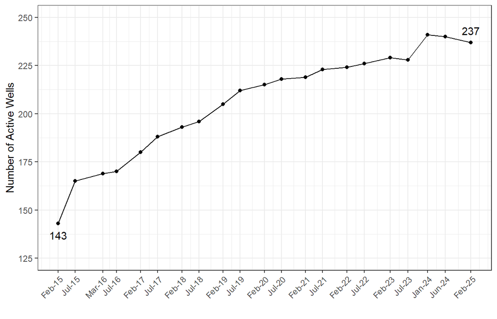

Wells by Region

| Region | Total | Telemetry | Non-Telemetry |
| --- | --- | --- | --- |
| West Coast | 82 | 42 | 40 |
| South Coast | 59 | 47 | 12 |
| Okanagan-Kootenay | 48 | 41 | 7 |
| Thompson-Cariboo | 27 | 6 | 21 |
| North East | 10 | 5 | 5 |
| Omineca | 6 | 6 | 0 |
| Skeena | 5 | 4 | 1 |

The West Coast Region has had a full-time, dedicated Groundwater Technician since 2006, and a second dedicated technician was added in 2024. The South Coast Region and the South Area (Okanagan-Kootenay) implemented a full-time, dedicated Groundwater Technician in January 2016. The remainder of the network is operated by partial FTEs working in their respective regional Water Authorizations teams who must balance the workloads of their core positions with work on the network.

### Data Approval and Well Performance

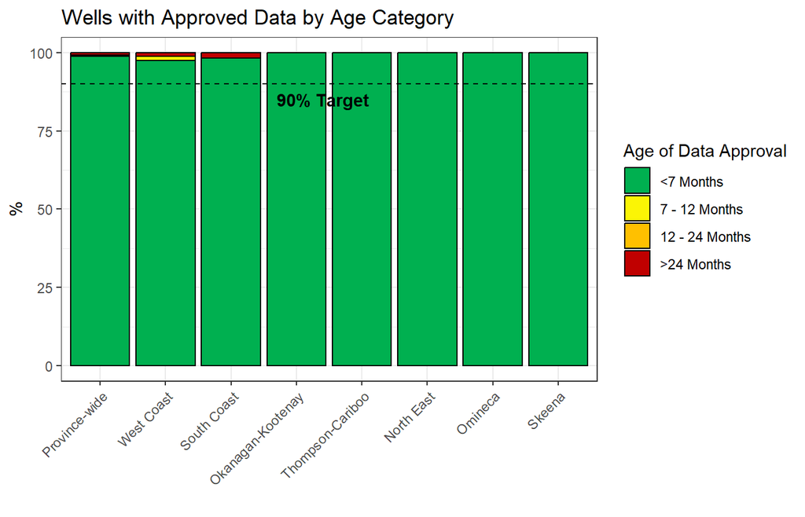

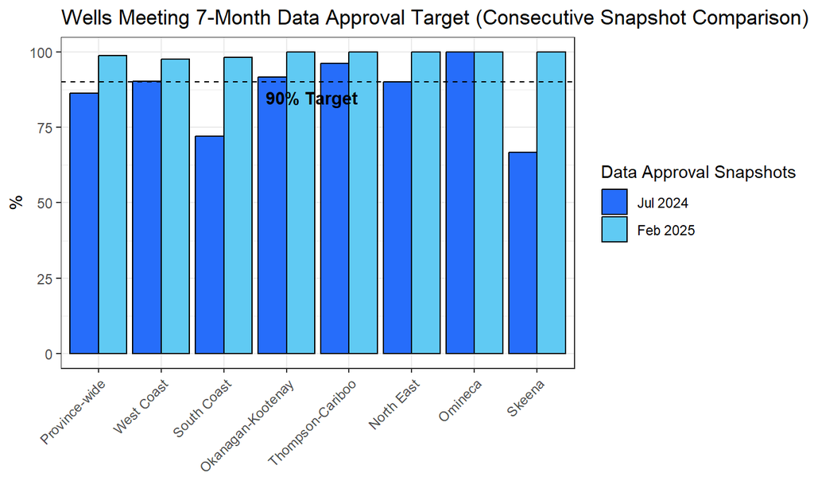

**Importance of this metric:** Stations must be visited every 6 months, with data graded and approved within 1 month of site visits, to ensure data quality as sensors will drift over time, and to ensure timely access to data (barring issues of seasonal well accessibility for particular sites). The policy of publishing publicly available water level data that has been approved within the past 7 months was implemented in 2015.

**Target:** Achieve 7-month data approval at ≥ 90% of stations (implemented in 2024).

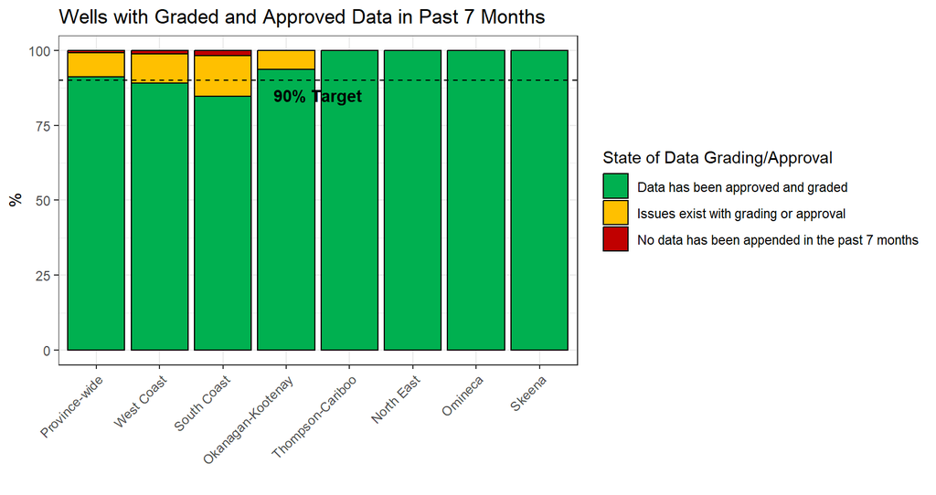

**Importance of this metric:** Grading of reviewed data is essential for communicating data quality to users. When data is reviewed and approved, it must be graded at that time. Moreover, there should be no wells that have no appended data available in the past 7 months; this is to ensure timely access to data (barring issues of seasonal well accessibility for particular sites). Grading of water level data was implemented in 2016.

Please note that there is a 2% tolerance applied to the calculation of this metric with regards to approved data to avoid flagging more minor discrepancies (i.e., if there is slightly more / less approved data vs. graded data for a well, this will not label the well as having issues with its grading).

**Target:** Have all approved data graded at ≥ 90% of stations (implemented in 2024).

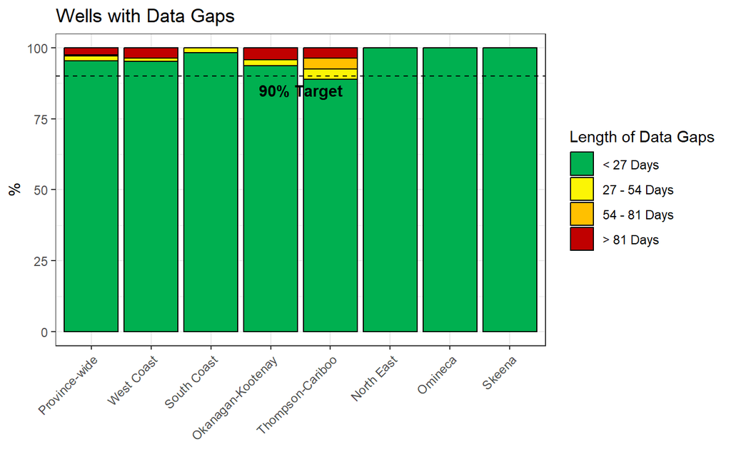

**Importance of this metric:** Gaps in the data record will adversely impact future analysis of the groundwater level data. To calculate long-term groundwater level trends, data gaps must be kept to less than 15% of the period of record (as per Environmental Reporting BC methodology for groundwater level trend analysis [updated from 25%, October 2024]). As such, regions strive to keep such gaps to a minimum. This chart displays the percent of wells that fall within designated data gap length categories between **Jan 01, 2024 and Jun 30, 2024** within each region. This data gap policy was implemented in 2024. Please note:

1. The data analyzed to determine the number of data gaps is from 6-month period ending 7 months ago, meaning field staff should have visited these sites and filled in data gaps by the time this latest snapshot is published.
2. Some gaps measured here are not permanent gaps as field staff may later be able to append data to those missing periods.

**Target:** Data gaps should be less than 27 days (in a 6-month period) at ≥ 90% stations (implemented in 2024).

## Map

[interactive chart not shown]

## Performance Over Time

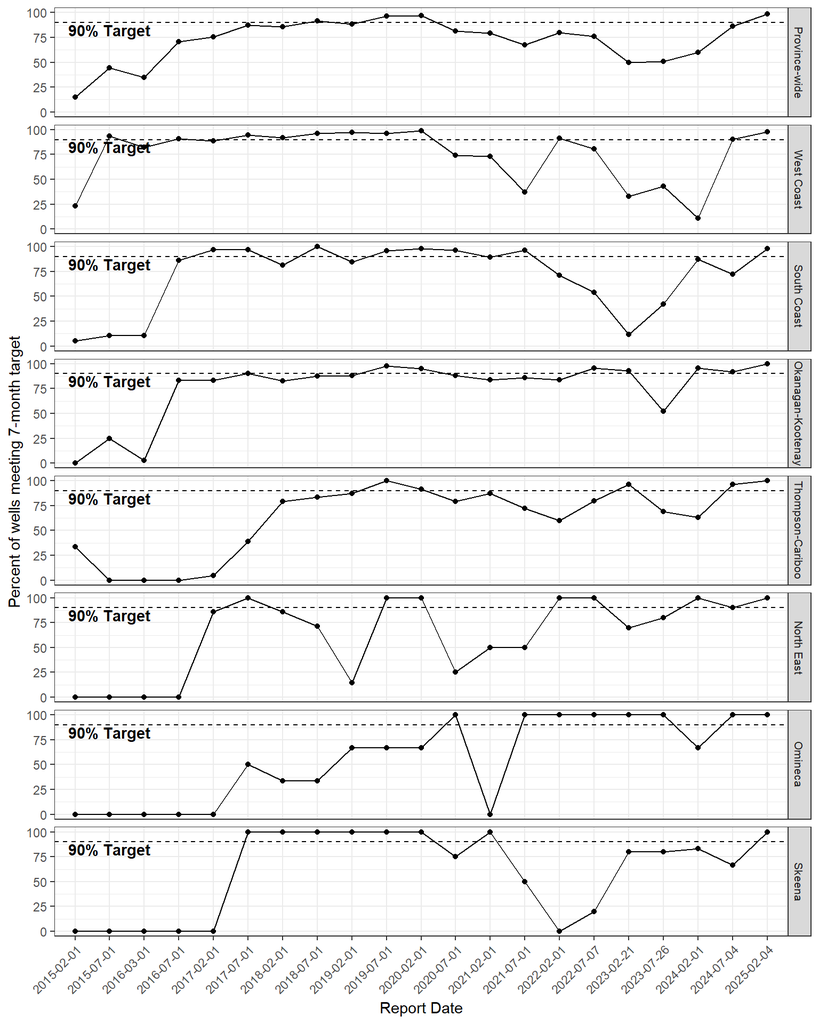

## Caveats

*This assessment was completed on Feb 04, 2025 and is current as of this date.

### Method:

All active PGOWN wells publicly available on the [PGOWN Interactive Map](https://governmentofbc.maps.arcgis.com/apps/webappviewer/index.html?id=b53cb0bf3f6848e79d66ffd09b74f00d) are assessed on a region-by-region basis. The water level data is downloaded for each well and the last month that the data is categorized as validated, is noted. For each region, the % of wells in that region with validated data greater than 7 months old is determined. For each region, the average age of data is determined based on the number of wells displayed on the interactive map at the time of the snapshot and the total age (in months) of the validated data.

*The number of active wells displayed on the interactive map may change from year to year as wells are added / removed from PGOWN (i.e. it is not static)

*This review checks the frequency of publicly available data validation, quality of systems operations (Aquarius Database / PGOWN Interactive Map) and communications, frequency of site visits, and overall efficiency of network protocols that have been implemented. This review and report can be used as one of several metrics for overall workload of PGOWN staff.